# ADP8

17회 복기 자료

```r
library(tidyverse)
library(data.table)
library(lubridate)
library(caret)
library(recipes)
library(rsample)
library(forecast)
library(GGally)
```

# 1 house price prediction

- 데이터 : califonia housing 데이터와 유사

https://www.kaggle.com/harlfoxem/housesalesprediction

```r
house <- fread("data/kc_house_data.csv")
house %>% names()
```

```
##  [1] "id"            "date"          "price"         "bedrooms"
##  [5] "bathrooms"     "sqft_living"   "sqft_lot"      "floors"
##  [9] "waterfront"    "view"          "condition"     "grade"
## [13] "sqft_above"    "sqft_basement" "yr_built"      "yr_renovated"
## [17] "zipcode"       "lat"           "long"          "sqft_living15"
## [21] "sqft_lot15"
```

```r
house <- house %>% select(-c(id, date, zipcode, sqft_living15, sqft_lot15, sqft_basement))
```

## 1.1 Description

| 변수 | 변수설명 |
| --- | --- |
| price | 주택 판매가격 |
| lat | 위도 |
| long | 경도 |
| bedrooms | 침실의 개수 |
| bathrooms | 욕실의 개수(0.5: 화장실 포함, 샤워실 x) |
| sqft_living | 주택 평 수 |
| sqft_lot | 땅 크기 |
| floors | 주택 층 수 |
| waterfront | 해안가가 보이는지 여부 |
| view | 건물 전망 등급 0~4 |
| condition | 건물의 전반적인 조건 1~5 |
| grade | 건물의 건축자재 및 디자인 우수성 등급 |
| yr_renovated | 건물의 리모델링 연도 |
| yr_built | 건물이 지어진 최초 연도 |

## 1.2 EDA

```r
house %>% glimpse()
```

```
## Rows: 21,613
## Columns: 15
## $ price        <dbl> 221900, 538000, 180000, 604000, 510000, 1225000, 257500, ~
## $ bedrooms     <int> 3, 3, 2, 4, 3, 4, 3, 3, 3, 3, 3, 2, 3, 3, 5, 4, 3, 4, 2, ~
## $ bathrooms    <dbl> 1.00, 2.25, 1.00, 3.00, 2.00, 4.50, 2.25, 1.50, 1.00, 2.5~
## $ sqft_living  <int> 1180, 2570, 770, 1960, 1680, 5420, 1715, 1060, 1780, 1890~
## $ sqft_lot     <int> 5650, 7242, 10000, 5000, 8080, 101930, 6819, 9711, 7470, ~
## $ floors       <dbl> 1.0, 2.0, 1.0, 1.0, 1.0, 1.0, 2.0, 1.0, 1.0, 2.0, 1.0, 1.~
## $ waterfront   <int> 0, 0, 0, 0, 0, 0, 0, 0, 0, 0, 0, 0, 0, 0, 0, 0, 0, 0, 0, ~
## $ view         <int> 0, 0, 0, 0, 0, 0, 0, 0, 0, 0, 0, 0, 0, 0, 0, 3, 0, 0, 0, ~
## $ condition    <int> 3, 3, 3, 5, 3, 3, 3, 3, 3, 3, 3, 4, 4, 4, 3, 3, 3, 4, 4, ~
## $ grade        <int> 7, 7, 6, 7, 8, 11, 7, 7, 7, 7, 8, 7, 7, 7, 7, 9, 7, 7, 7,~
## $ sqft_above   <int> 1180, 2170, 770, 1050, 1680, 3890, 1715, 1060, 1050, 1890~
## $ yr_built     <int> 1955, 1951, 1933, 1965, 1987, 2001, 1995, 1963, 1960, 200~
## $ yr_renovated <int> 0, 1991, 0, 0, 0, 0, 0, 0, 0, 0, 0, 0, 0, 0, 0, 0, 0, 0, ~
## $ lat          <dbl> 47.5112, 47.7210, 47.7379, 47.5208, 47.6168, 47.6561, 47.~
## $ long         <dbl> -122.257, -122.319, -122.233, -122.393, -122.045, -122.00~
```

```r
house %>% summary()
```

```
##      price            bedrooms        bathrooms      sqft_living
##  Min.   :  75000   Min.   : 0.000   Min.   :0.000   Min.   :  290
##  1st Qu.: 321950   1st Qu.: 3.000   1st Qu.:1.750   1st Qu.: 1427
##  Median : 450000   Median : 3.000   Median :2.250   Median : 1910
##  Mean   : 540088   Mean   : 3.371   Mean   :2.115   Mean   : 2080
##  3rd Qu.: 645000   3rd Qu.: 4.000   3rd Qu.:2.500   3rd Qu.: 2550
##  Max.   :7700000   Max.   :33.000   Max.   :8.000   Max.   :13540
##     sqft_lot           floors        waterfront            view
##  Min.   :    520   Min.   :1.000   Min.   :0.000000   Min.   :0.0000
##  1st Qu.:   5040   1st Qu.:1.000   1st Qu.:0.000000   1st Qu.:0.0000
##  Median :   7618   Median :1.500   Median :0.000000   Median :0.0000
##  Mean   :  15107   Mean   :1.494   Mean   :0.007542   Mean   :0.2343
##  3rd Qu.:  10688   3rd Qu.:2.000   3rd Qu.:0.000000   3rd Qu.:0.0000
##  Max.   :1651359   Max.   :3.500   Max.   :1.000000   Max.   :4.0000
##    condition         grade          sqft_above      yr_built
##  Min.   :1.000   Min.   : 1.000   Min.   : 290   Min.   :1900
##  1st Qu.:3.000   1st Qu.: 7.000   1st Qu.:1190   1st Qu.:1951
##  Median :3.000   Median : 7.000   Median :1560   Median :1975
##  Mean   :3.409   Mean   : 7.657   Mean   :1788   Mean   :1971
##  3rd Qu.:4.000   3rd Qu.: 8.000   3rd Qu.:2210   3rd Qu.:1997
##  Max.   :5.000   Max.   :13.000   Max.   :9410   Max.   :2015
##   yr_renovated         lat             long
##  Min.   :   0.0   Min.   :47.16   Min.   :-122.5
##  1st Qu.:   0.0   1st Qu.:47.47   1st Qu.:-122.3
##  Median :   0.0   Median :47.57   Median :-122.2
##  Mean   :  84.4   Mean   :47.56   Mean   :-122.2
##  3rd Qu.:   0.0   3rd Qu.:47.68   3rd Qu.:-122.1
##  Max.   :2015.0   Max.   :47.78   Max.   :-121.3
```

```r
house %>% is.na() %>% colSums()
```

```
##        price     bedrooms    bathrooms  sqft_living     sqft_lot       floors
##            0            0            0            0            0            0
##   waterfront         view    condition        grade   sqft_above     yr_built
##            0            0            0            0            0            0
## yr_renovated          lat         long
##            0            0            0
```

```r
house <- house %>%
  mutate(
         waterfront = as.factor(waterfront),
         view = as.factor(view),
         condition = as.factor(condition),
         age=2018-yr_built
         ) %>%
  select(-yr_built)
```

```r
house$price %>% summary()
```

```
##    Min. 1st Qu.  Median    Mean 3rd Qu.    Max.
##   75000  321950  450000  540088  645000 7700000
```

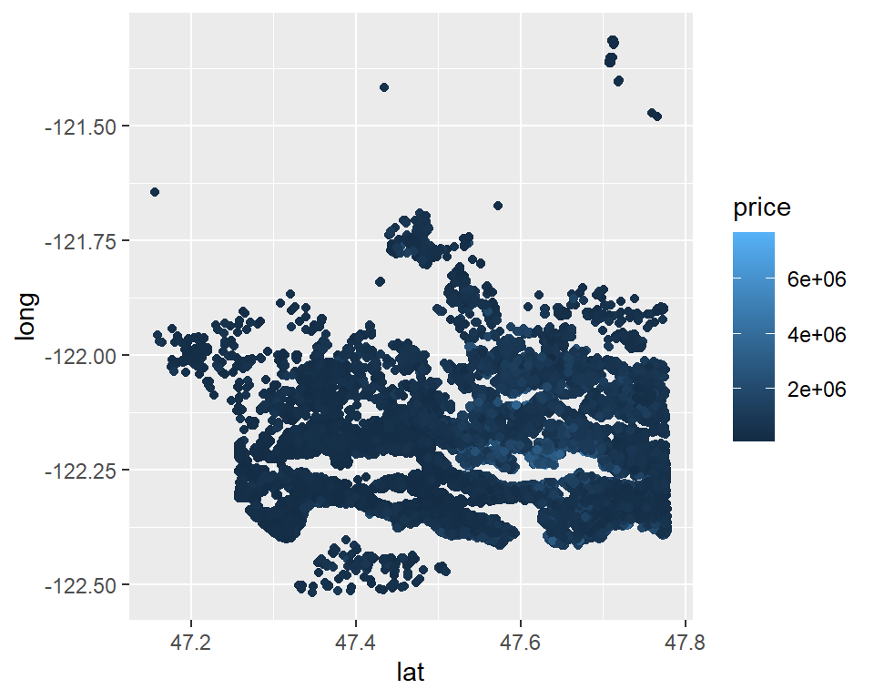

```r
house %>%
  ggplot(aes(x = lat, y = long, color = price)) +
  geom_point()
```

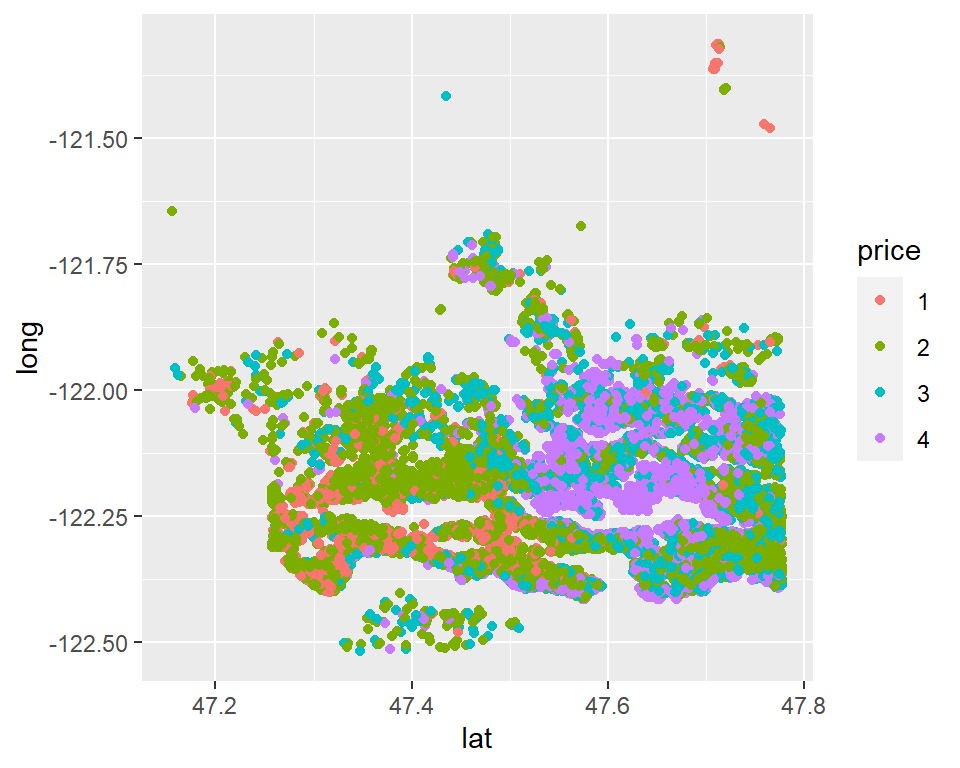

```r
house %>%
  mutate(price = case_when(price <= 250000 ~ 1,
                           price <=500000 ~ 2,
                           price <= 750000 ~ 3,
                           TRUE ~ 4),
         price = as.factor(price)) %>%
  ggplot(aes(x = lat, y = long, color = price)) +
  geom_point()
```

```r
house <- house %>%
  mutate(lat_ind = ifelse(lat>=47.5,0,1),
         lat_ind = as.factor(lat_ind))
```

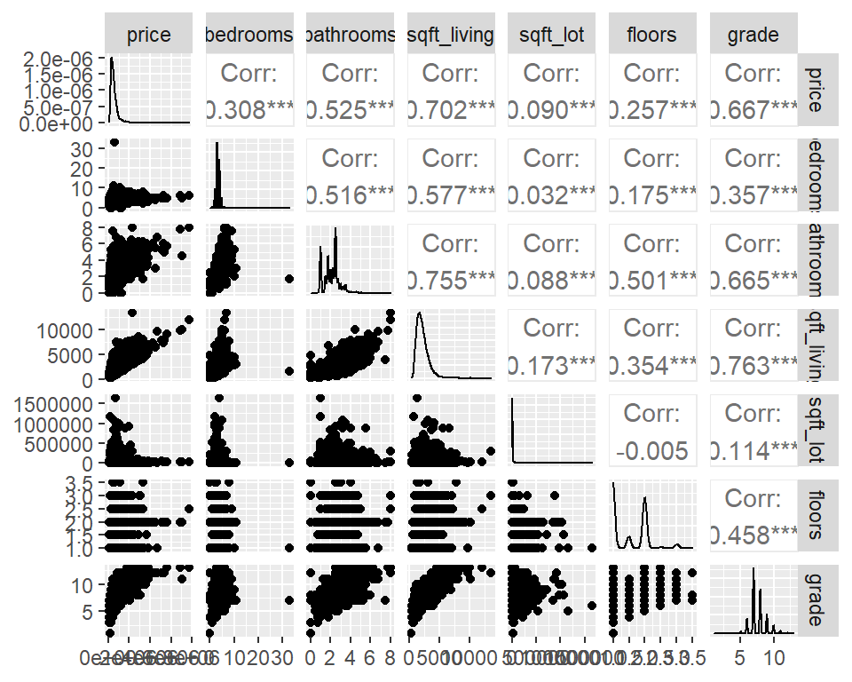

```r
house %>%
  select_if(is.numeric) %>%
  ggpairs(columns = 1:7)
```

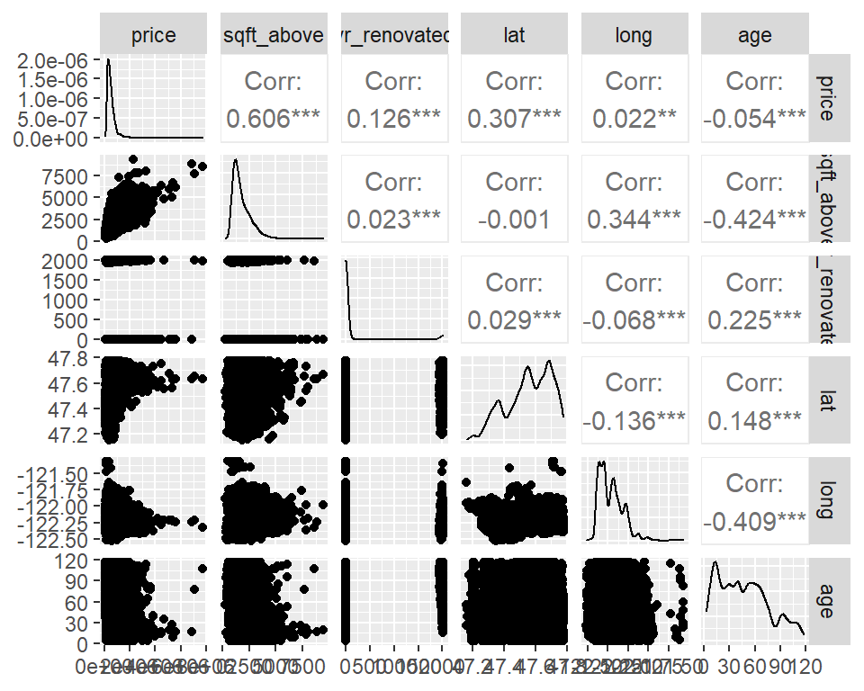

```r
house %>%
  select_if(is.numeric) %>%
  ggpairs(columns = c(1, 8:12))
```

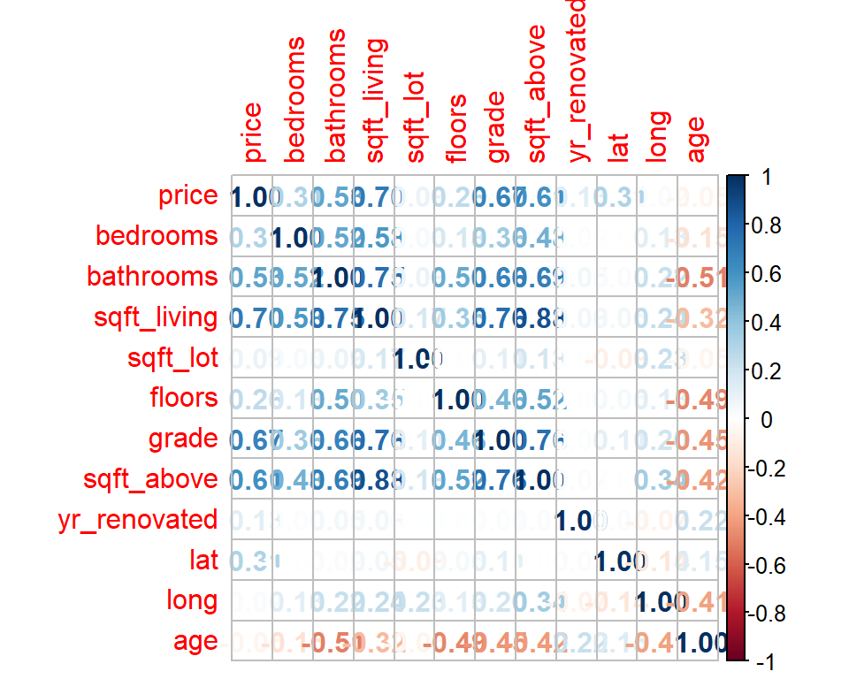

```r
house %>%
  select_if(is.numeric) %>%
  cor() %>%
  corrplot::corrplot(method = "number")
```

## 1.3 데이터분할

- valid를 왜 나눠야하는지 모르겠음

```r
library(rsample)

idx <- initial_split(house, prop = 0.7, strata = price)
train <- training(idx)
test <- testing(idx)
```

## 1.4 train/valid/test 시각화 제시

- valid set 제외하고 train/test 결과만 시각화함

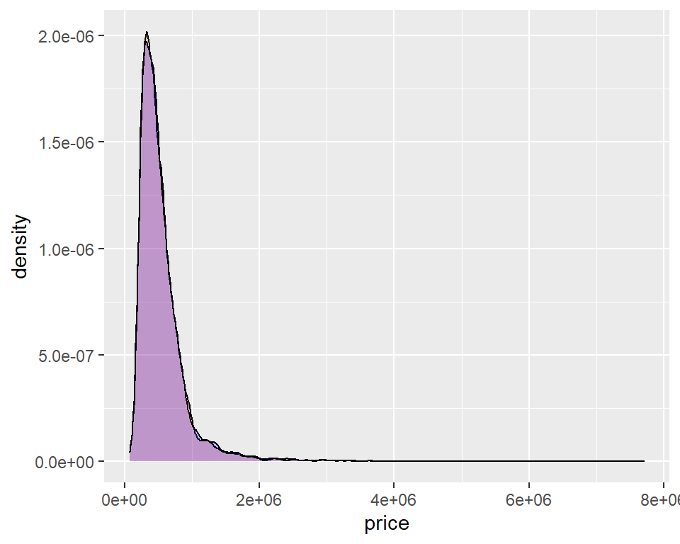

```r
ggplot() +
  geom_density(data = train, aes(x = price),fill = "red", alpha = 0.2) +
  geom_density(data = test, aes(x = price), fill = "blue",alpha = 0.2)
```

## 1.5 Modeling

- sqft_living, sqft_above 변수 간에 상관관계가 높기 때문에 교호작용항을 추가함

**교호작용을 고려한 다중회귀 수행**

```r
train %>% glimpse()
```

```
## Rows: 15,127
## Columns: 16
## $ price        <dbl> 221900, 257500, 291850, 229500, 310000, 189000, 230000, 2~
## $ bedrooms     <int> 3, 3, 3, 3, 3, 2, 3, 5, 2, 2, 3, 3, 3, 3, 4, 3, 5, 2, 3, ~
## $ bathrooms    <dbl> 1.00, 2.25, 1.50, 1.00, 1.00, 1.00, 1.00, 2.50, 1.50, 1.5~
## $ sqft_living  <int> 1180, 1715, 1060, 1780, 1430, 1200, 1250, 2270, 1070, 119~
## $ sqft_lot     <int> 5650, 6819, 9711, 7470, 19901, 9850, 9774, 6300, 9643, 12~
## $ floors       <dbl> 1.0, 2.0, 1.0, 1.0, 1.5, 1.0, 1.0, 2.0, 1.0, 3.0, 1.0, 2.~
## $ waterfront   <fct> 0, 0, 0, 0, 0, 0, 0, 0, 0, 0, 0, 0, 0, 0, 0, 0, 0, 0, 0, ~
## $ view         <fct> 0, 0, 0, 0, 0, 0, 0, 0, 0, 0, 0, 0, 0, 0, 0, 0, 0, 0, 0, ~
## $ condition    <fct> 3, 3, 3, 3, 4, 4, 4, 3, 3, 3, 4, 3, 3, 5, 3, 4, 5, 4, 3, ~
## $ grade        <int> 7, 7, 7, 7, 7, 7, 7, 8, 7, 7, 6, 8, 7, 7, 7, 7, 7, 7, 7, ~
## $ sqft_above   <int> 1180, 1715, 1060, 1050, 1430, 1200, 1250, 2270, 1070, 119~
## $ yr_renovated <int> 0, 0, 0, 0, 0, 0, 0, 0, 0, 0, 0, 0, 0, 0, 0, 0, 0, 0, 0, ~
## $ lat          <dbl> 47.5112, 47.3097, 47.4095, 47.5123, 47.7558, 47.3089, 47.~
## $ long         <dbl> -122.257, -122.327, -122.315, -122.337, -122.229, -122.21~
## $ age          <dbl> 63, 23, 55, 58, 91, 97, 49, 23, 33, 13, 59, 15, 64, 93, 1~
## $ lat_ind      <fct> 0, 1, 1, 0, 0, 1, 1, 1, 1, 0, 1, 1, 1, 0, 1, 1, 1, 0, 1, ~
```

```r
fit <- lm(price ~ . + sqft_living*sqft_above, data = train)
summary(fit)
```

```
##
## Call:
## lm(formula = price ~ . + sqft_living * sqft_above, data = train)
##
## Residuals:
##      Min       1Q   Median       3Q      Max
## -3874410   -91326   -11544    67753  2549840
##
## Coefficients:
##                          Estimate Std. Error t value Pr(>|t|)
## (Intercept)            -1.628e+07  1.812e+06  -8.986  < 2e-16 ***
## bedrooms               -1.155e+04  2.134e+03  -5.411 6.37e-08 ***
## bathrooms               4.144e+04  3.683e+03  11.250  < 2e-16 ***
## sqft_living             4.410e+01  5.609e+00   7.863 4.00e-15 ***
## sqft_lot               -4.045e-02  3.805e-02  -1.063    0.288
## floors                  9.298e+02  4.035e+03   0.230    0.818
## waterfront1             5.797e+05  2.220e+04  26.113  < 2e-16 ***
## view1                   1.086e+05  1.265e+04   8.585  < 2e-16 ***
## view2                   6.356e+04  7.705e+03   8.249  < 2e-16 ***
## view3                   1.426e+05  1.072e+04  13.297  < 2e-16 ***
## view4                   2.448e+05  1.634e+04  14.985  < 2e-16 ***
## condition2             -2.054e+03  4.578e+04  -0.045    0.964
## condition3             -1.695e+04  4.263e+04  -0.398    0.691
## condition4              2.720e+04  4.263e+04   0.638    0.523
## condition5              6.213e+04  4.287e+04   1.449    0.147
## grade                   1.038e+05  2.375e+03  43.725  < 2e-16 ***
## sqft_above             -8.025e+01  6.110e+00 -13.134  < 2e-16 ***
## yr_renovated            2.866e+01  4.171e+00   6.872 6.58e-12 ***
## lat                     1.562e+05  2.031e+04   7.692 1.54e-14 ***
## long                   -6.844e+04  1.308e+04  -5.234 1.68e-07 ***
## age                     1.934e+03  8.301e+01  23.294  < 2e-16 ***
## lat_ind1               -1.548e+05  6.282e+03 -24.635  < 2e-16 ***
## sqft_living:sqft_above  3.962e-02  1.097e-03  36.135  < 2e-16 ***
## ---
## Signif. codes:  0 '***' 0.001 '**' 0.01 '*' 0.05 '.' 0.1 ' ' 1
##
## Residual standard error: 189600 on 15104 degrees of freedom
## Multiple R-squared:  0.7345, Adjusted R-squared:  0.7341
## F-statistic:  1899 on 22 and 15104 DF,  p-value: < 2.2e-16
```

**변수선택**

- cp, adj-rsquare, bic 기준으로 **price ~ bathrooms + waterfront+ view + grade + sqft_above + age + lat_ind + sqft_living * sqft_above 모델 선택**

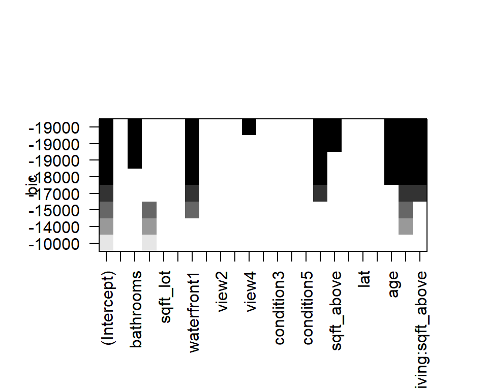

```r
library(leaps)

fit_leaps <- regsubsets(price ~ . + sqft_living * sqft_above, data = train)

plot(fit_leaps) # bic 기준
```

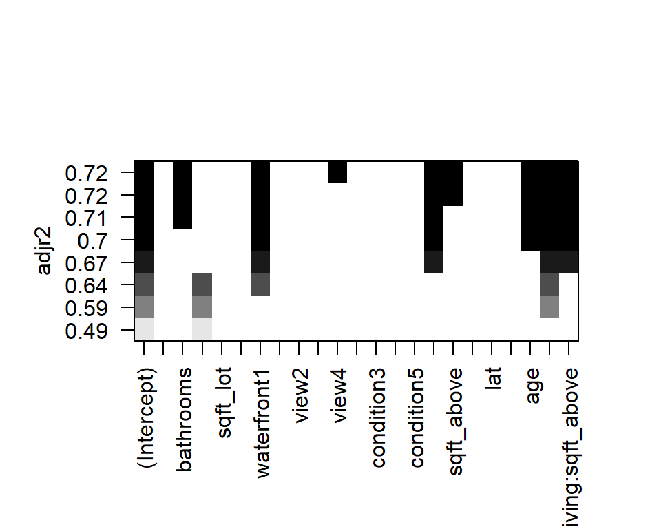

```r
plot(fit_leaps, scale = "adjr2")
```

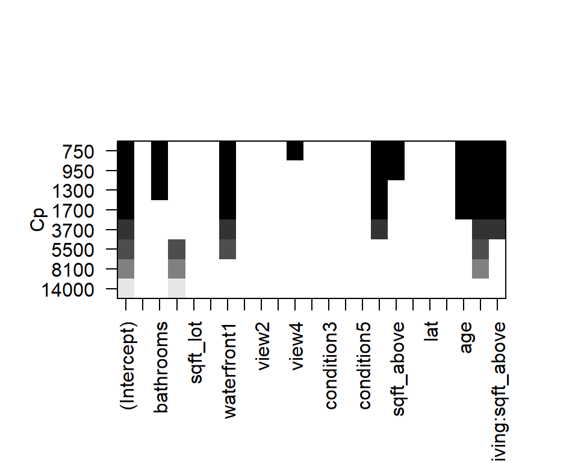

```r
plot(fit_leaps, scale = "Cp")
```

```r
fit1 <- lm(price ~ bathrooms + waterfront+ view + grade + sqft_above + age + lat_ind + sqft_living * sqft_above, train)
```

- aic, bic 기준으로 보면 price ~ bedrooms + bathrooms + sqft_living + waterfront + view + condition + grade + sqft_above + yr_renovated + lat + long + age + lat_ind + sqft_living:sqft_above 선택

```r
library(MASS)
stepAIC(fit, trace=F)
```

```
##
## Call:
## lm(formula = price ~ bedrooms + bathrooms + sqft_living + waterfront +
##     view + condition + grade + sqft_above + yr_renovated + lat +
##     long + age + lat_ind + sqft_living:sqft_above, data = train)
##
## Coefficients:
##            (Intercept)                bedrooms               bathrooms
##             -1.663e+07              -1.142e+04               4.175e+04
##            sqft_living             waterfront1                   view1
##              4.358e+01               5.798e+05               1.085e+05
##                  view2                   view3                   view4
##              6.341e+04               1.419e+05               2.448e+05
##             condition2              condition3              condition4
##             -2.742e+03              -1.690e+04               2.712e+04
##             condition5                   grade              sqft_above
##              6.220e+04               1.038e+05              -7.965e+01
##           yr_renovated                     lat                    long
##              2.870e+01               1.555e+05              -7.159e+04
##                    age                lat_ind1  sqft_living:sqft_above
##              1.925e+03              -1.555e+05               3.954e-02
```

```r
stepAIC(fit, k=log(nrow(train)), trace = F)
```

```
##
## Call:
## lm(formula = price ~ bedrooms + bathrooms + sqft_living + waterfront +
##     view + condition + grade + sqft_above + yr_renovated + lat +
##     long + age + lat_ind + sqft_living:sqft_above, data = train)
##
## Coefficients:
##            (Intercept)                bedrooms               bathrooms
##             -1.663e+07              -1.142e+04               4.175e+04
##            sqft_living             waterfront1                   view1
##              4.358e+01               5.798e+05               1.085e+05
##                  view2                   view3                   view4
##              6.341e+04               1.419e+05               2.448e+05
##             condition2              condition3              condition4
##             -2.742e+03              -1.690e+04               2.712e+04
##             condition5                   grade              sqft_above
##              6.220e+04               1.038e+05              -7.965e+01
##           yr_renovated                     lat                    long
##              2.870e+01               1.555e+05              -7.159e+04
##                    age                lat_ind1  sqft_living:sqft_above
##              1.925e+03              -1.555e+05               3.954e-02
```

```r
fit2=lm(formula = price ~ bedrooms + bathrooms + sqft_living + waterfront +
    view + condition + grade + sqft_above + yr_renovated + lat +
    long + age + lat_ind + sqft_living:sqft_above, data = train)
```

- 모수 간결성의 원칙에 따라 fit1 선택

```r
AIC(fit1, fit2)
```

```
##      df      AIC
## fit1 14 410939.6
## fit2 22 410616.6
```

```r
BIC(fit1, fit2)
```

```
##      df      BIC
## fit1 14 411046.3
## fit2 22 410784.4
```

```r
summary(fit1)
```

```
##
## Call:
## lm(formula = price ~ bathrooms + waterfront + view + grade +
##     sqft_above + age + lat_ind + sqft_living * sqft_above, data = train)
##
## Residuals:
##      Min       1Q   Median       3Q      Max
## -3919591   -91029   -11018    68392  2581935
##
## Coefficients:
##                          Estimate Std. Error t value Pr(>|t|)
## (Intercept)            -5.447e+05  1.722e+04 -31.639  < 2e-16 ***
## bathrooms               4.378e+04  3.472e+03  12.607  < 2e-16 ***
## waterfront1             5.904e+05  2.239e+04  26.365  < 2e-16 ***
## view1                   1.117e+05  1.274e+04   8.766  < 2e-16 ***
## view2                   6.372e+04  7.759e+03   8.212 2.35e-16 ***
## view3                   1.434e+05  1.077e+04  13.312  < 2e-16 ***
## view4                   2.555e+05  1.648e+04  15.503  < 2e-16 ***
## grade                   1.073e+05  2.350e+03  45.673  < 2e-16 ***
## sqft_above             -9.289e+01  5.453e+00 -17.036  < 2e-16 ***
## age                     2.520e+03  6.977e+01  36.120  < 2e-16 ***
## lat_ind1               -1.904e+05  3.594e+03 -52.974  < 2e-16 ***
## sqft_living             4.057e+01  5.084e+00   7.981 1.56e-15 ***
## sqft_above:sqft_living  4.025e-02  1.064e-03  37.825  < 2e-16 ***
## ---
## Signif. codes:  0 '***' 0.001 '**' 0.01 '*' 0.05 '.' 0.1 ' ' 1
##
## Residual standard error: 191700 on 15114 degrees of freedom
## Multiple R-squared:  0.7285, Adjusted R-squared:  0.7283
## F-statistic:  3379 on 12 and 15114 DF,  p-value: < 2.2e-16
```

```r
summary(fit2)
```

```
##
## Call:
## lm(formula = price ~ bedrooms + bathrooms + sqft_living + waterfront +
##     view + condition + grade + sqft_above + yr_renovated + lat +
##     long + age + lat_ind + sqft_living:sqft_above, data = train)
##
## Residuals:
##      Min       1Q   Median       3Q      Max
## -3875585   -91363   -11543    67720  2554800
##
## Coefficients:
##                          Estimate Std. Error t value Pr(>|t|)
## (Intercept)            -1.663e+07  1.772e+06  -9.384  < 2e-16 ***
## bedrooms               -1.142e+04  2.128e+03  -5.367 8.14e-08 ***
## bathrooms               4.175e+04  3.562e+03  11.721  < 2e-16 ***
## sqft_living             4.358e+01  5.437e+00   8.015 1.18e-15 ***
## waterfront1             5.798e+05  2.220e+04  26.123  < 2e-16 ***
## view1                   1.085e+05  1.264e+04   8.579  < 2e-16 ***
## view2                   6.341e+04  7.703e+03   8.232  < 2e-16 ***
## view3                   1.419e+05  1.070e+04  13.260  < 2e-16 ***
## view4                   2.448e+05  1.634e+04  14.982  < 2e-16 ***
## condition2             -2.742e+03  4.578e+04  -0.060    0.952
## condition3             -1.690e+04  4.263e+04  -0.396    0.692
## condition4              2.712e+04  4.263e+04   0.636    0.525
## condition5              6.220e+04  4.287e+04   1.451    0.147
## grade                   1.038e+05  2.374e+03  43.738  < 2e-16 ***
## sqft_above             -7.965e+01  5.566e+00 -14.310  < 2e-16 ***
## yr_renovated            2.870e+01  4.167e+00   6.889 5.83e-12 ***
## lat                     1.555e+05  2.029e+04   7.661 1.95e-14 ***
## long                   -7.159e+04  1.261e+04  -5.678 1.39e-08 ***
## age                     1.925e+03  8.105e+01  23.751  < 2e-16 ***
## lat_ind1               -1.555e+05  6.216e+03 -25.010  < 2e-16 ***
## sqft_living:sqft_above  3.954e-02  1.089e-03  36.312  < 2e-16 ***
## ---
## Signif. codes:  0 '***' 0.001 '**' 0.01 '*' 0.05 '.' 0.1 ' ' 1
##
## Residual standard error: 189600 on 15106 degrees of freedom
## Multiple R-squared:  0.7345, Adjusted R-squared:  0.7341
## F-statistic:  2089 on 20 and 15106 DF,  p-value: < 2.2e-16
```

**등분산성 가정**

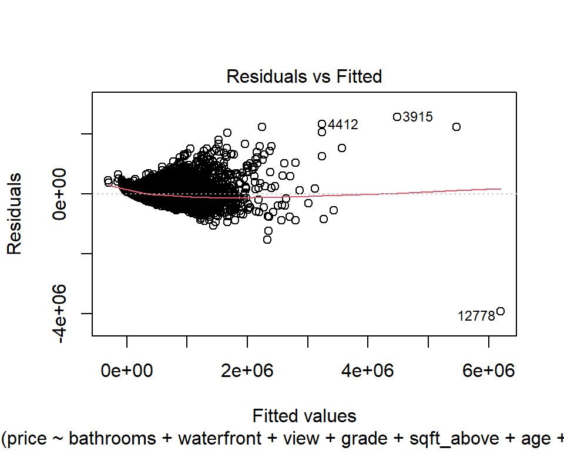

```r
plot(fit1, which = 1)
```

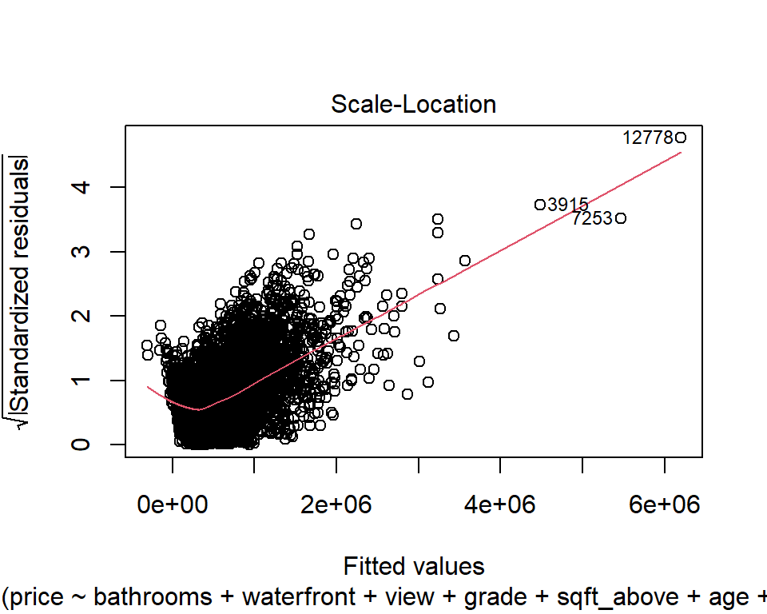

```r
plot(fit1, which = 3)
```

```r
car::ncvTest(fit1)
```

```
## Non-constant Variance Score Test
## Variance formula: ~ fitted.values
## Chisquare = 46842.81, Df = 1, p = < 2.22e-16
```

**정규성 가정**

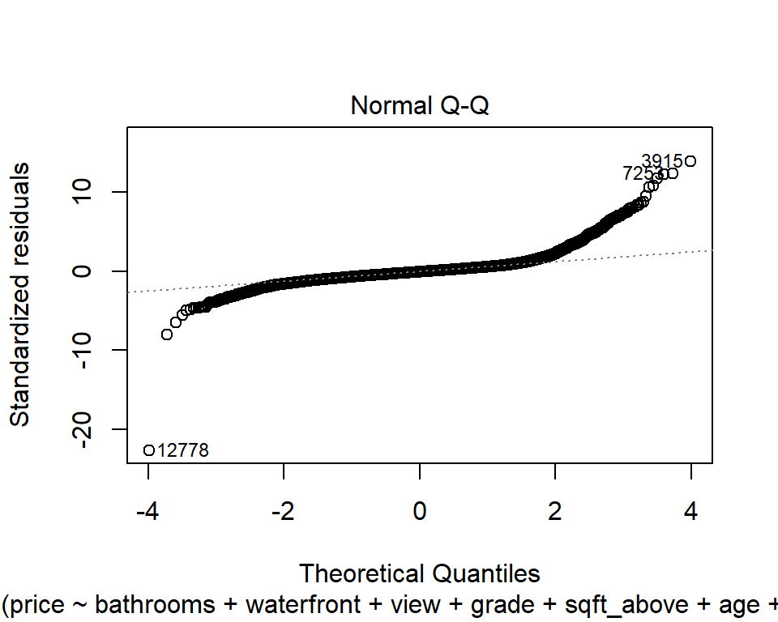

```r
plot(fit1, which = 2)
```

```r
#shapiro.test(residuals(fit1)) # error : sample size must be between 3 and 5000
# nortest   1.0-4
library(nortest)
ad.test(residuals(fit1))
```

```
##
##  Anderson-Darling normality test
##
## data:  residuals(fit1)
## A = 496.96, p-value < 2.2e-16
```

**독립성 가정**

```r
car::durbinWatsonTest(fit1)
```

```
##  lag Autocorrelation D-W Statistic p-value
##    1      0.08762432      1.824656       0
##  Alternative hypothesis: rho != 0
```

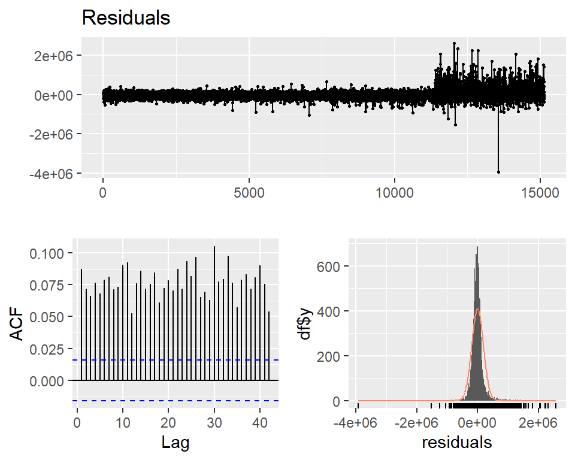

```
##
##  Breusch-Godfrey test for serial correlation of order up to 16
##
## data:  Residuals
## LM test = 913.21, df = 16, p-value < 2.2e-16
```

```r
checkresiduals(fit1)
```

**선형성 가정**

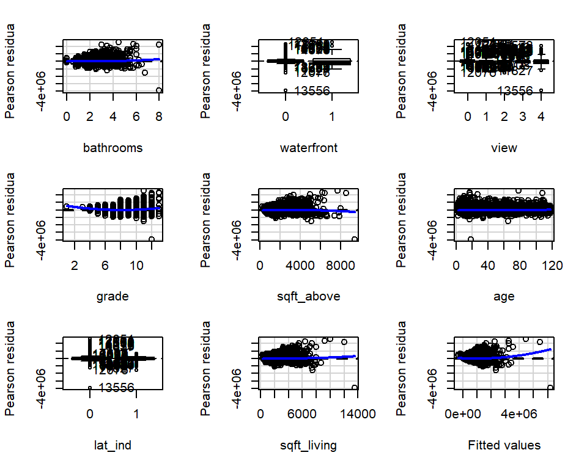

```
##             Test stat Pr(>|Test stat|)
## bathrooms      7.8568        4.206e-15 ***
## waterfront
## view
## grade         19.1709        < 2.2e-16 ***
## sqft_above   -14.7152        < 2.2e-16 ***
## age            2.2975           0.0216 *
## lat_ind
## sqft_living   11.5165        < 2.2e-16 ***
## Tukey test    22.0307        < 2.2e-16 ***
## ---
## Signif. codes:  0 '***' 0.001 '**' 0.01 '*' 0.05 '.' 0.1 ' ' 1
```

```r
# car::crPlots(fit1) : interaction term 있을 때는 적용 x
car::residualPlots(fit1)
```

**다중공선성**

```r
car::vif(fit1)
```

```
##                            GVIF Df GVIF^(1/(2*Df))
## bathrooms              2.945448  1        1.716231
## waterfront             1.598214  1        1.264205
## view                   1.828398  4        1.078348
## grade                  3.136998  1        1.771157
## sqft_above             8.356436  1        2.890750
## age                    1.728696  1        1.314799
## lat_ind                1.128539  1        1.062327
## sqft_living            8.945807  1        2.990954
## sqft_above:sqft_living 9.619766  1        3.101575
```

**log 변환**

- 실제 시험 때는 데이터가 적어서 회귀모형에 잘 적합할 수 있도록 나올 것으로 예상
- 현재 데이터는 관측치가 너무 많아서 가정을 엄격하게 확인하기 불가능..
- 절차만 참고

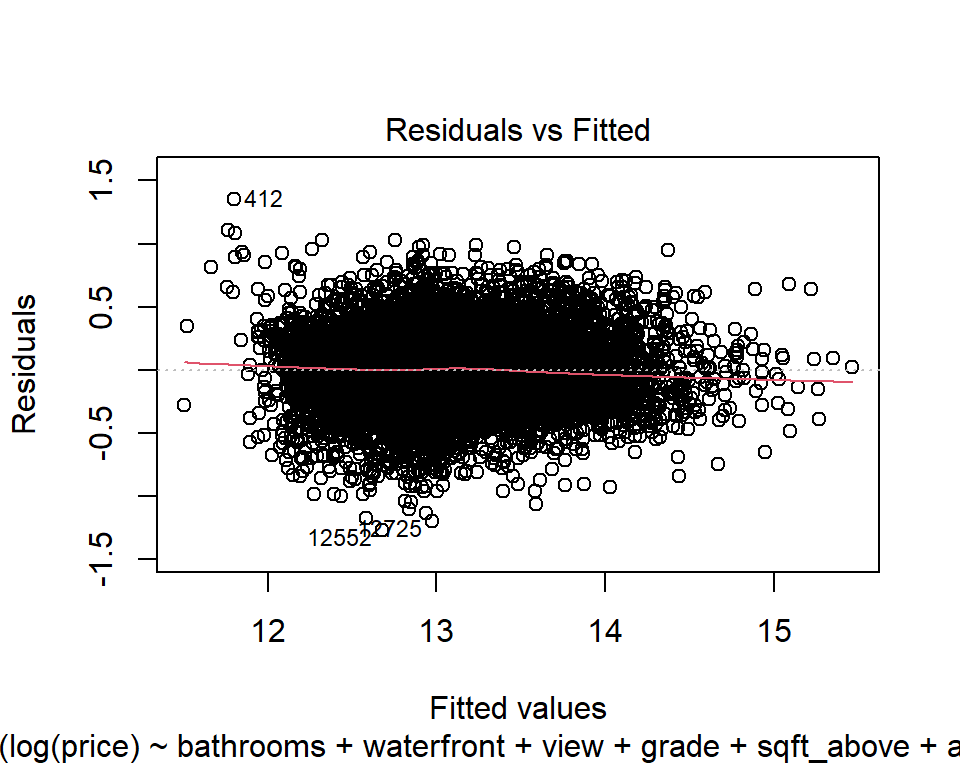

```r
fit1_log <- lm(formula = log(price) ~ bathrooms + waterfront + view + grade +
    sqft_above + age + lat_ind + sqft_living * sqft_above, data = train)

plot(fit1_log, which = 1)
```

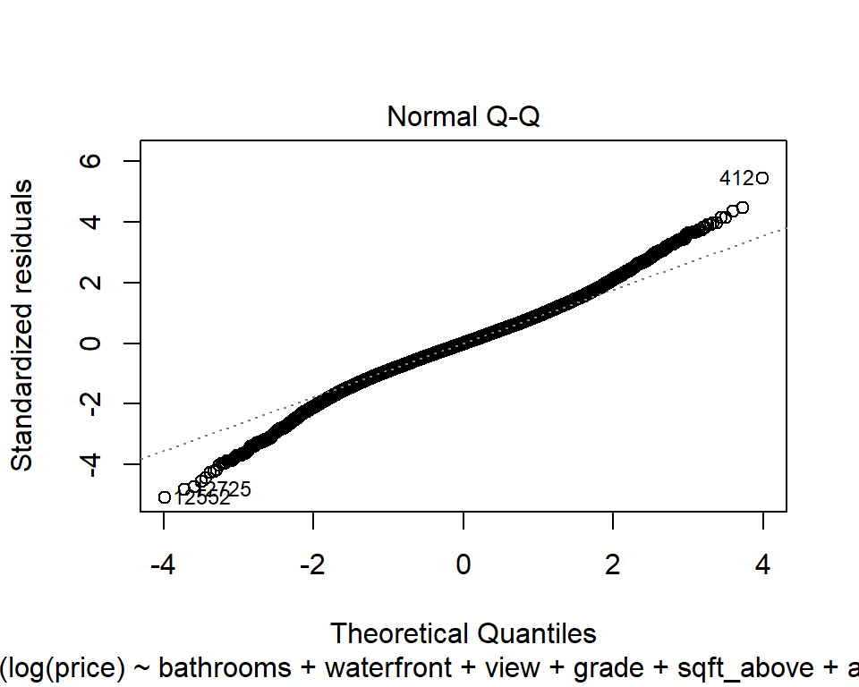

```r
plot(fit1_log, which = 2)
```

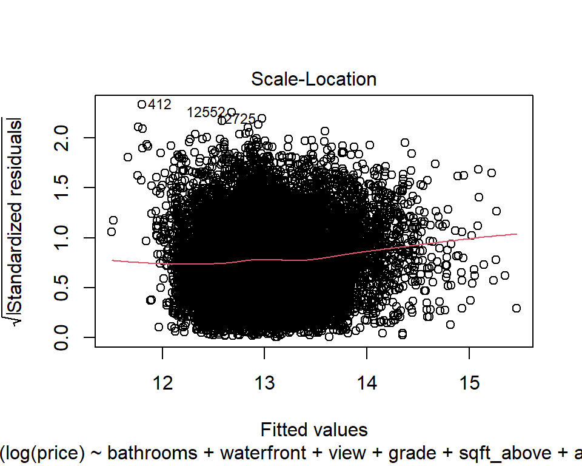

```r
plot(fit1_log, which = 3)
```

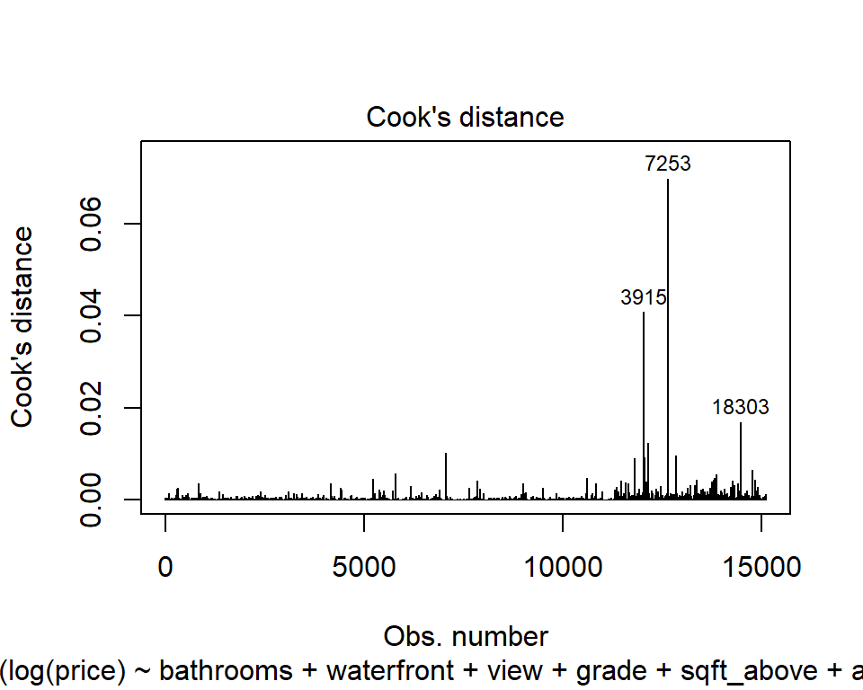

```r
plot(fit1_log, which = 4)
```

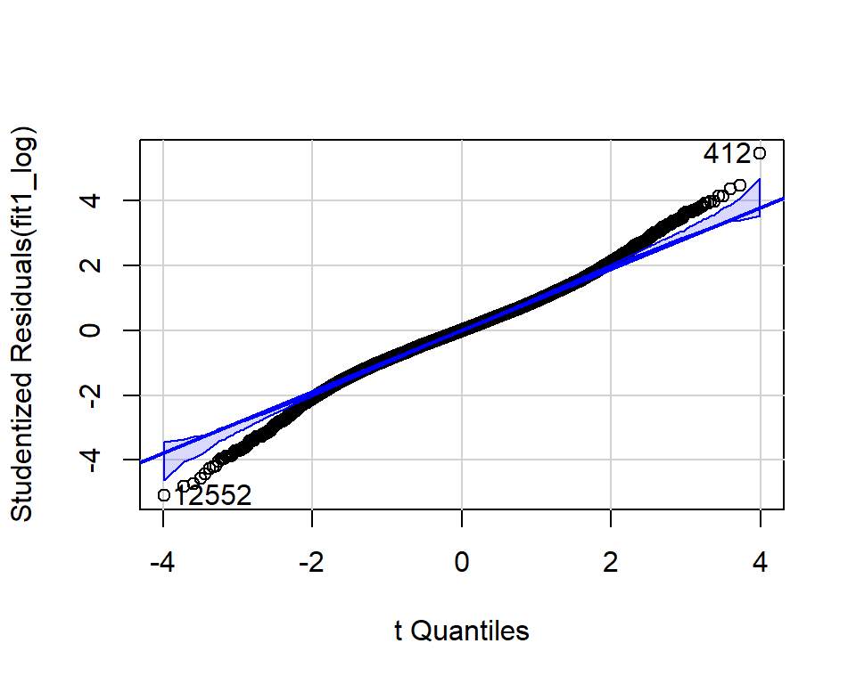

```
## 12552   412
##  2335  7667
```

```r
car::qqPlot(fit1_log)
```

```r
car::ncvTest(fit1_log)
```

```
## Non-constant Variance Score Test
## Variance formula: ~ fitted.values
## Chisquare = 8.927194, Df = 1, p = 0.0028096
```

```r
ad.test(residuals(fit1_log))
```

```
##
##  Anderson-Darling normality test
##
## data:  residuals(fit1_log)
## A = 29.802, p-value < 2.2e-16
```

```r
pred <- predict(fit1_log, newdata = test)

forecast::accuracy(pred, test$price)
```

```
##                ME     RMSE      MAE      MPE     MAPE
## Test set 540486.8 652635.5 540486.8 99.99686 99.99686
```

```r
caret::R2(pred, test$price)
```

```
## [1] 0.6403213
```

## 1.6 기계학습 모형 3가지 MSE, MAPE, R2 비교

- 자료의 크기에 영향을 받는 측도 : MAE, MSE, R2
- 자료의 크기에 영향을 받지 않는 측도 : MAPE
- 이 데이터에서는 MAPE가 적절
- MAPE는 관측값이 0을 갖는 경우 사용 X, 발산

```r
rf_gridsearch <- train(price ~ .,
                       data = train,
                       method = 'rf')

pred <- predict(rf_gridsearch, newdata = test)
print(RMSE(pred, test$price))


xgb_gridsearch <- train(price ~ .,
                       data = train,
                       method = 'xgbTree')

pred <- predict(xgb_gridsearch, newdata = test)
print(RMSE(pred, test$price))


lasso_gridsearch <- train(medv ~ .,
                       data = train,
                       method = 'glmnet')
lasso_gridsearch
pred <- predict(lasso_gridsearch, newdata = test)
print(RMSE(pred, test$price))
print(R2(pred, test$price))
forecast::accuracy(pred, test$price) # mape 나옴
```

[output not shown]

# 2 covid19

```r
library(readr)

file_path <- "https://www.sharpsightlabs.com/datasets/covid19/covid_data_2020-05-08.csv"
covid_data <- read_delim(file_path,delim = ";") # 임의의 구분자로 된 파일을 읽을 때 사용
covid_data %>% summary()
```

```
##    country           subregion              date                 lat
##  Length:28462       Length:28462       Min.   :2020-01-22   Min.   :-51.796
##  Class :character   Class :character   1st Qu.:2020-02-17   1st Qu.:  6.877
##  Mode  :character   Mode  :character   Median :2020-03-15   Median : 23.488
##                                        Mean   :2020-03-15   Mean   : 21.259
##                                        3rd Qu.:2020-04-11   3rd Qu.: 41.153
##                                        Max.   :2020-05-07   Max.   : 71.707
##
##       long           confirmed            dead           recovered
##  Min.   :-135.00   Min.   :      0   Min.   :    0.0   Min.   :     0
##  1st Qu.: -19.02   1st Qu.:      0   1st Qu.:    0.0   1st Qu.:     0
##  Median :  20.92   Median :     11   Median :    0.0   Median :     0
##  Mean   :  22.43   Mean   :   3470   Mean   :  228.6   Mean   :  1009
##  3rd Qu.:  78.00   3rd Qu.:    285   3rd Qu.:    3.0   3rd Qu.:    71
##  Max.   : 178.06   Max.   :1257023   Max.   :75662.0   Max.   :195036
##                                                        NA's   :1605
##    new_cases
##  Min.   :-10034.0
##  1st Qu.:     0.0
##  Median :     0.0
##  Mean   :   136.4
##  3rd Qu.:     6.0
##  Max.   : 36188.0
##  NA's   :266
```

```r
covid_data %>% glimpse()
```

```
## Rows: 28,462
## Columns: 9
## $ country   <chr> "Afghanistan", "Afghanistan", "Afghanistan", "Afghanistan", ~
## $ subregion <chr> NA, NA, NA, NA, NA, NA, NA, NA, NA, NA, NA, NA, NA, NA, NA, ~
## $ date      <date> 2020-01-22, 2020-01-23, 2020-01-24, 2020-01-25, 2020-01-26,~
## $ lat       <dbl> 33, 33, 33, 33, 33, 33, 33, 33, 33, 33, 33, 33, 33, 33, 33, ~
## $ long      <dbl> 65, 65, 65, 65, 65, 65, 65, 65, 65, 65, 65, 65, 65, 65, 65, ~
## $ confirmed <dbl> 0, 0, 0, 0, 0, 0, 0, 0, 0, 0, 0, 0, 0, 0, 0, 0, 0, 0, 0, 0, ~
## $ dead      <dbl> 0, 0, 0, 0, 0, 0, 0, 0, 0, 0, 0, 0, 0, 0, 0, 0, 0, 0, 0, 0, ~
## $ recovered <dbl> 0, 0, 0, 0, 0, 0, 0, 0, 0, 0, 0, 0, 0, 0, 0, 0, 0, 0, 0, 0, ~
## $ new_cases <dbl> NA, 0, 0, 0, 0, 0, 0, 0, 0, 0, 0, 0, 0, 0, 0, 0, 0, 0, 0, 0,~
```

```r
covid_data %>%
  group_by(country) %>%
  summarise(sum = sum(dead)) %>% # 데이터에 전체 인구 x
  arrange(-sum) %>%
  top_n(5)
```

```
## # A tibble: 5 x 2
##   country            sum
##   <chr>            <dbl>
## 1 US             1528930
## 2 Italy           964566
## 3 Spain           780614
## 4 France          684966
## 5 United Kingdom  672450
```

## 2.2 시각화

- 국가별 일일 확진자, 누적확진자, 일일사망자, 누적사망자 시계열 그래프 출력

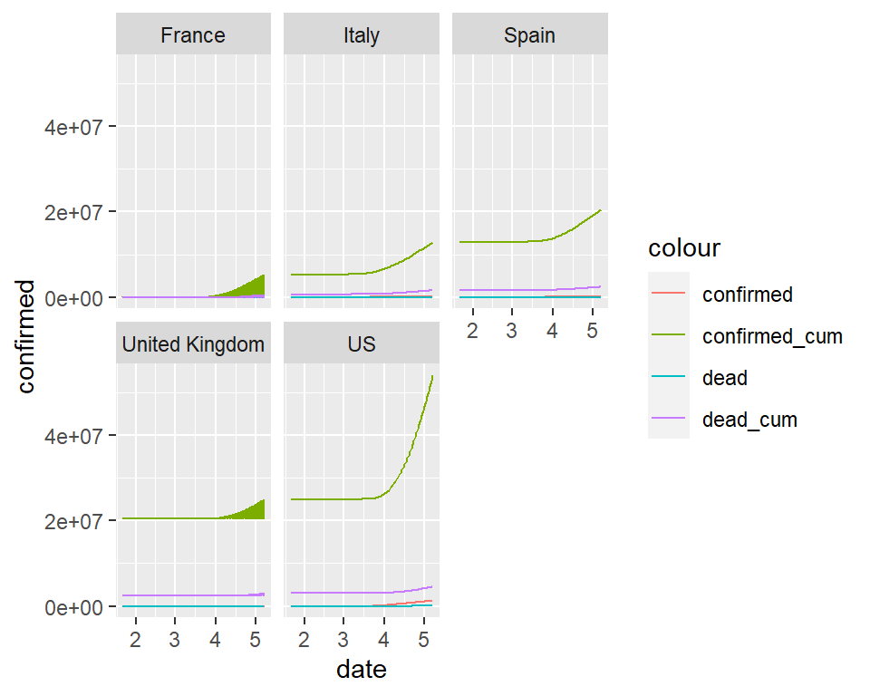

```r
covid_data %>%
  filter(country%in%c("US", "Italy", "Spain", "France", "United Kingdom")) %>%
  mutate(dead_cum = cumsum(dead),
         confirmed_cum = cumsum(confirmed)) %>%
  ggplot() +
  geom_line(aes(x = date, y = confirmed, color = "confirmed")) +
  geom_line(aes(x = date, y = confirmed_cum, color = "confirmed_cum")) +
  geom_line(aes(x = date, y = dead, color = "dead")) +
  geom_line(aes(x = date, y = dead_cum, color = "dead_cum")) +
  facet_wrap(~country)
```

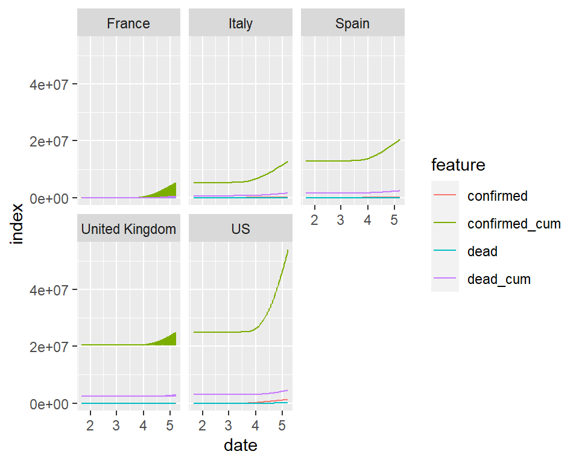

```r
covid_data %>%
  filter(country%in%c("US", "Italy", "Spain", "France", "United Kingdom")) %>%
  mutate(dead_cum = cumsum(dead),
         confirmed_cum = cumsum(confirmed)) %>%
  pivot_longer(cols = c("confirmed", "confirmed_cum", "dead", "dead_cum"), names_to = "feature", values_to = "index") %>%
  ggplot(aes(x = date, y = index, group = feature, color = feature)) +
  geom_line() +
  facet_wrap(~country)
```

## 2.3 위험지수

- 위험지수 개발, 이유 설명
- 위험지수가 높은 국가들 10개 선정해서 시각화
- 한국의 코로나 확진자를 예측(선형 시계열 모델 + 비선형시계열 모델)

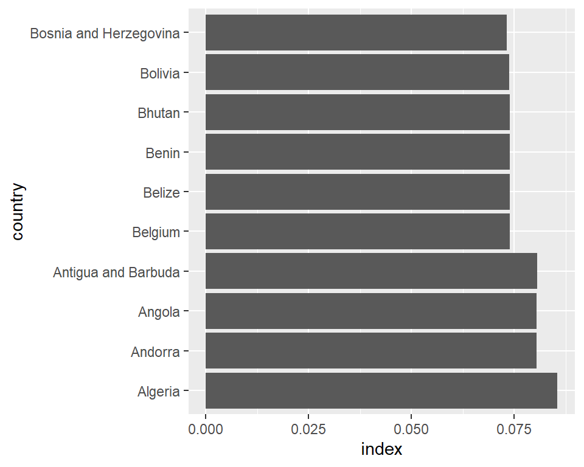

```r
covid_data %>%
  mutate(dead_cum = cumsum(dead),
         confirmed_cum = cumsum(confirmed)) %>%
  filter(date == max(date)) %>%
  mutate(index = dead_cum/confirmed_cum) %>%
  arrange(-index) %>%
  top_n(10) %>%
  #mutate(country = fct_reorder(country, desc(country))) %>%
  ggplot(aes(x = country, y = index)) +
  geom_bar(stat = "identity") +
  coord_flip()
```

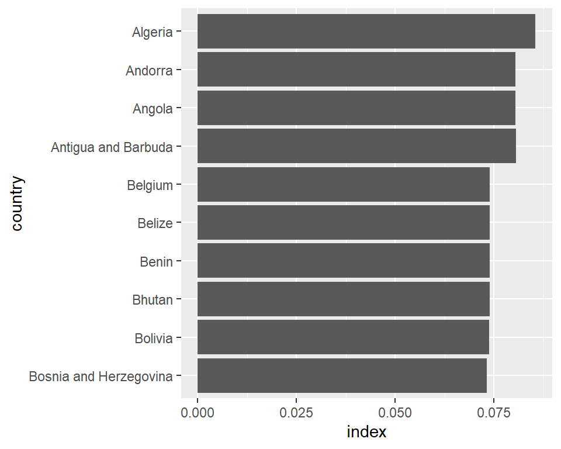

```r
covid_data %>%
  mutate(dead_cum = cumsum(dead),
         confirmed_cum = cumsum(confirmed)) %>%
  filter(date == max(date)) %>%
  mutate(index = dead_cum/confirmed_cum) %>%
  arrange(-index) %>%
  top_n(10) %>%
  mutate(country = fct_reorder(country, desc(country))) %>%
  ggplot(aes(x = country, y = index)) +
  geom_bar(stat = "identity") +
  coord_flip()
```

```r
korea <- covid_data %>%
  filter(country == "Korea, South")
korea %>% head()
```

```
## # A tibble: 6 x 9
##   country      subregion date         lat  long confirmed  dead recovered new_cases
##   <chr>        <chr>     <date>     <dbl> <dbl>     <dbl> <dbl>     <dbl>     <dbl>
## 1 Korea, South <NA>      2020-01-22    36   128         1     0         0        NA
## 2 Korea, South <NA>      2020-01-23    36   128         1     0         0         0
## 3 Korea, South <NA>      2020-01-24    36   128         2     0         0         1
## 4 Korea, South <NA>      2020-01-25    36   128         2     0         0         0
## 5 Korea, South <NA>      2020-01-26    36   128         3     0         0         1
## 6 Korea, South <NA>      2020-01-27    36   128         4     0         0         1
```

```r
korea %>% tail()
```

```
## # A tibble: 6 x 9
##   country      subregion date         lat  long confirmed  dead recovered new_cases
##   <chr>        <chr>     <date>     <dbl> <dbl>     <dbl> <dbl>     <dbl>     <dbl>
## 1 Korea, South <NA>      2020-05-02    36   128     10793   250      9183        13
## 2 Korea, South <NA>      2020-05-03    36   128     10801   252      9217         8
## 3 Korea, South <NA>      2020-05-04    36   128     10804   254      9283         3
## 4 Korea, South <NA>      2020-05-05    36   128     10806   255      9333         2
## 5 Korea, South <NA>      2020-05-06    36   128     10810   256      9419         4
## 6 Korea, South <NA>      2020-05-07    36   128     10822   256      9484        12
```

```r
covid_ts <- ts(korea$confirmed, frequency = 365)
summary(forecast(auto.arima(covid_ts, seasonal = F)))
```

```
##
## Forecast method: ARIMA(0,2,1)
##
## Model Information:
## Series: covid_ts
## ARIMA(0,2,1)
##
## Coefficients:
##           ma1
##       -0.2452
## s.e.   0.0826
##
## sigma^2 estimated as 5713:  log likelihood=-602.67
## AIC=1209.34   AICc=1209.46   BIC=1214.65
##
## Error measures:
##                     ME     RMSE      MAE      MPE     MAPE MASE       ACF1
## Training set 0.1228184 74.51984 35.61363 1.590174 5.163948  NaN -0.0267739
##
## Forecasts:
##          Point Forecast        Lo 80     Hi 80         Lo 95      Hi 95
## 1.293151       10831.95   10735.0853  10928.82  1.068381e+04   10980.10
## 1.295890       10841.91   10646.2597  11037.56  1.054269e+04   11141.13
## 1.298630       10851.86   10539.8109  11163.91  1.037462e+04   11329.10
## 1.301370       10861.82   10417.5546  11306.08  1.018238e+04   11541.25
## 1.304110       10871.77   10281.0526  11462.49  9.968346e+03   11775.19
## 1.306849       10881.72   10131.5213  11631.93  9.734388e+03   12029.06
## 1.309589       10891.68    9969.9235  11813.43  9.481976e+03   12301.38
## 1.312329       10901.63    9797.0414  12006.22  9.212307e+03   12590.96
## 1.315068       10911.59    9613.5247  12209.65  8.926373e+03   12896.80
## 1.317808       10921.54    9419.9238  12423.15  8.625017e+03   13218.06
## 1.320548       10931.49    9216.7122  12646.27  8.308962e+03   13554.02
## 1.323288       10941.45    9004.3030  12878.59  7.978841e+03   13904.05
## 1.326027       10951.40    8783.0603  13119.74  7.635210e+03   14267.59
## 1.328767       10961.35    8553.3083  13369.40  7.278566e+03   14644.14
## 1.331507       10971.31    8315.3383  13627.28  6.909353e+03   15033.27
## 1.334247       10981.26    8069.4135  13893.11  6.527974e+03   15434.55
## 1.336986       10991.22    7815.7732  14166.66  6.134795e+03   15847.64
## 1.339726       11001.17    7554.6367  14447.70  5.730152e+03   16272.19
## 1.342466       11011.12    7286.2055  14736.04  5.314353e+03   16707.90
```

[output cut: 696 more lines]

```
## 3.252055       17949.01 -792207.3892 828105.40 -1.221078e+06 1256976.29
## 3.254795       17958.96 -793893.3289 829811.25 -1.223662e+06 1259579.89
## 3.257534       17968.91 -795580.4503 831518.28 -1.226247e+06 1262185.30
## 3.260274       17978.87 -797268.7525 833226.49 -1.228835e+06 1264792.51
## 3.263014       17988.82 -798958.2348 834935.88 -1.231424e+06 1267401.53
## 3.265753       17998.78 -800648.8963 836646.45 -1.234015e+06 1270012.35
## 3.268493       18008.73 -802340.7362 838358.19 -1.236608e+06 1272624.97
## 3.271233       18018.68 -804033.7537 840071.12 -1.239202e+06 1275239.39
## 3.273973       18028.64 -805727.9479 841785.22 -1.241798e+06 1277855.62
## 3.276712       18038.59 -807423.3182 843500.50 -1.244396e+06 1280473.64
## 3.279452       18048.54 -809119.8636 845216.95 -1.246996e+06 1283093.46
## 3.282192       18058.50 -810817.5833 846934.58 -1.249598e+06 1285715.07
## 3.284932       18068.45 -812516.4766 848653.38 -1.252202e+06 1288338.48
## 3.287671       18078.41 -814216.5426 850373.36 -1.254807e+06 1290963.69
## 3.290411       18088.36 -815917.7805 852094.50 -1.257414e+06 1293590.68
```

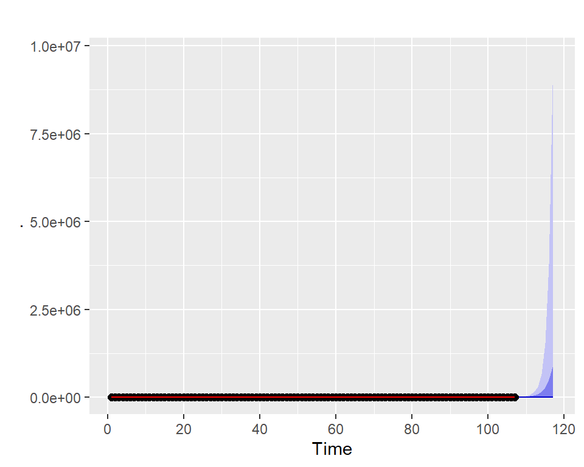

```r
window(korea$confirmed) %>%
  splinef(lambda = 0) %>%
  autoplot()
```

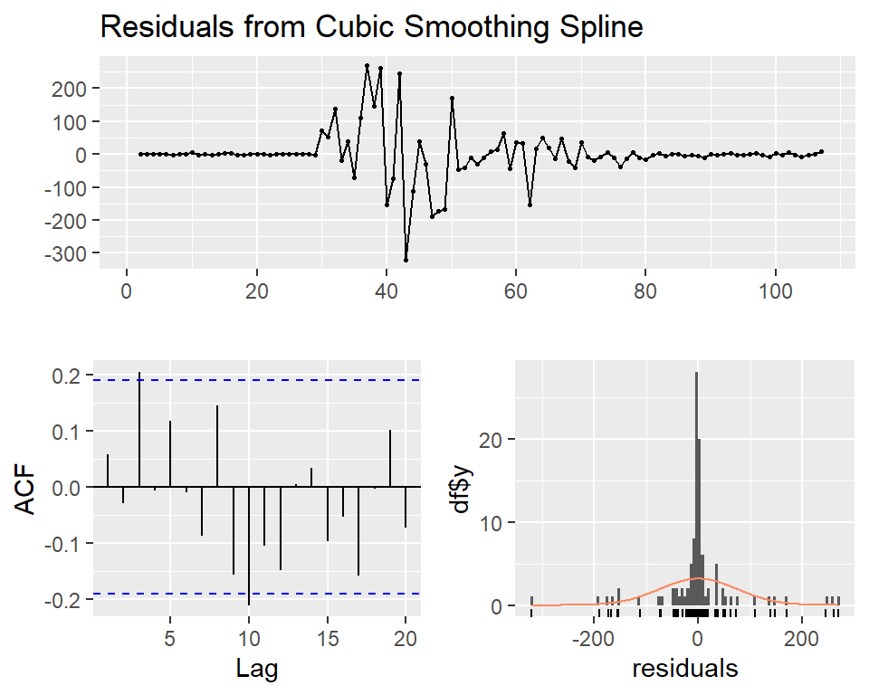

```r
window(korea$confirmed) %>%
  splinef() %>%
  checkresiduals()
```